# Image Classification in Python

Image Classification

**Introduction**

The dataset used is the Dog Vs Cats which is the collection of images of dogs and cats. The subset of images (1002 for the training set and 100 for the test set) is considered from the dataset consisting of 25000 images. The objective is to build models to classify whether images contain either a dog or a cat. We will be comparing various classification models (machine learning algorithms and deep learning algorithms) and compute the accuracy of models and thereby selecting the most accurate model after fine tuning it.

**Various Steps involved:**

1. **Preprocessing:** Loading and displaying the images,resizing the images,normalisation of the image data, dimension reduction using PCA, Training and Validation splits
2. **Building Models:** K-Nearest Neighbors, Support Vector Machine, Random Forest and Convolutional Neural Network (CNN)
3. **Comparison of the Accuracy Scores:** Before and after applying dimension reduction using PCA
4. **Hyperparameter Tuning:** Hyperparameter Tuning of the best model

**Importing the required libraries**

```python
import numpy as np
import pandas as pd
import matplotlib.pyplot as plt
import seaborn as sns
import cv2
import os
from sklearn.model_selection import train_test_split
from tensorflow import keras
from tensorflow.keras.models import Sequential
from tensorflow.keras.layers import Conv2D, MaxPooling2D, Dropout, Flatten, Dense, Activation
from sklearn.model_selection import cross_val_score
from sklearn.metrics import accuracy_score
from sklearn.neighbors import KNeighborsClassifier
from sklearn.tree import DecisionTreeClassifier
from sklearn.svm import SVC
from sklearn.ensemble import RandomForestClassifier
from sklearn.decomposition import PCA
from keras.wrappers.scikit_learn import KerasClassifier
from sklearn.model_selection import GridSearchCV
```

1. **numpy:** To perform scientific computing and data manipulation on multi-dimensional arrays and matrices
2. **pandas:** Used for data manipulation and analysis
3. **matplotlib and seaborn:** For Data Visualisation
4. **cv2:** OpenCV library is used to load and manipulate the images. Images are converted to n-dimensional numpy arrays.
5. **sklearn:** Scikit-learn is used for implementing machine learning algorithms, feature extractions and computing various scores of predicted models
6. **tensorflow:** TensorFlow Keras is used for implementing deep learning algorithms

**Loading the images and the extracting the labels**

```python
# Listing the images from the train folder
training_set_images_path = "C:/Users/dalal/Desktop/CIT Modules + Lectures + Materials/- Sem 2/Applied Machine Learning - COMP9060_26651/Project 3/Project3_files/Project3_files/data/train/"
training_set_images = os.listdir(training_set_images_path)

# From the filenames of the images extracting the label names ('cat' and 'dog') and storing in a list
labels = []
for pet_name in training_set_images:
    if "cat" in pet_name:
        labels.append('cat')
    else:
        labels.append('dog')

# Creating a data frame with the filenames of the images and labels
training_dataframe = pd.DataFrame({'filename': training_set_images,'label': labels})
training_dataframe
```

|  | filename | label |
| --- | --- | --- |
| 0 | cat.0.jpg | cat |
| 1 | cat.1.jpg | cat |
| 2 | cat.10.jpg | cat |
| 3 | cat.100.jpg | cat |
| 4 | cat.101.jpg | cat |
| ... | ... | ... |
| 997 | dog.95.jpg | dog |
| 998 | dog.96.jpg | dog |
| 999 | dog.97.jpg | dog |
| 1000 | dog.98.jpg | dog |
| 1001 | dog.99.jpg | dog |

1002 rows × 2 columns

We will be loading the images of the training set as a first step. The dataframe above consists of the filenames of the images and the label asscociated with it. From the filenames of the images we extract the label names ('cat' and 'dog') and store it in a list.

```python
# Counts of the images: cats and dogs

training_dataframe['label'].value_counts()
```

```
cat    501
dog    501
Name: label, dtype: int64
```

The training set consists of 501 images of cats and 501 images of dogs.

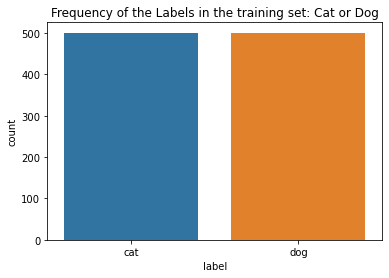

```python
# Visualizing the counts of cats and dogs from the training set in a Bar Plot

count_labels = sns.countplot(training_dataframe['label'])
count_labels.set_title('Frequency of the Labels in the training set: Cat or Dog')
```

**Loading the images, Resizing, and Normalization**

```python
# We will now load the images of the training set in form of an array
training_set_image_data = []

for image in training_set_images:
    # Reading the image using imread function
    original_image = cv2.imread(os.path.join(training_set_images_path,image))

    #Convert the image to RGB (Original image)
    image_rgb = cv2.cvtColor(original_image,cv2.COLOR_BGR2RGB)

    # Rescaling the image to 350 width X 350 height (350 X 350)
    image_rescale = cv2.resize(image_rgb,(350, 350))

    training_set_image_data.append(image_rescale)
```

Using imread function from the OpenCV library, we read the images from the training set. Image is converted into array for the algorithms to take the input. The image would be 3-dimensional having the width, height and the colour channels (For e.g., 250 X 240 X 3). Original images are in the RGB colour. RGB color frames are of three layers, one for each color in RGB. Those three color layers are referred to as channels. To maintain consistency across all images of varying size for the machine learning and deep learning algorithms, resizing of all the images to a fixed size is required. This was achieved using OpenCV's resize function. We converted all the training images to have 350 width X 350 height (350 X 350). One of the loaded image after resizing is shown below which has the shape now of (350, 350, 3).

```
(350, 350, 3)
```

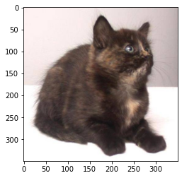

```python
plt.imshow(training_set_image_data[100])
print(training_set_image_data[100].shape)
```

**Reshaping and Normalization**

```python
# Converting the image data matrix into 4-dimensional numpy array using reshape
training_set_image_data = np.array(training_set_image_data).reshape(-1,350,350,3)

# Normalizing the image matrix data
training_set_image_data = training_set_image_data/255

training_set_image_data.shape
```

```
(1002, 350, 350, 3)
```

We are reshaping the image data into the 4-dimensional shape (number of images, width, height, channels) for the input parameters to Convolutional Neural Network. Each pixel has value ranging between 0 to 255 which shows the various density of black and white colors. It is important for the machine learning and deep learning algorithms to have scaled data. For normalize the data by dividing each pixel by 255 to have values in the range of 0 to 1. After normalization, the shape of the training image data input array is in the form (number of images, width, height, channels). In our case, the shape is (1002, 350, 350, 3). Below is the image of the cat after normalizing the values of the pixels.

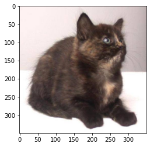

```python
plt.imshow(training_set_image_data[100])
```

We now convert the labels 'cat' and 'dog' into numeric values '0' for cat and '1' for dog for the algorithms to understand.

```python
# Converting the labels into numeric values for the algorithms to understand

training_dataframe["label"] = training_dataframe["label"].replace({"cat":0,"dog":1})
```

**Building Models**

**Summary:**

**Machine Learning Models: K-Nearest Neighbors, Support Vector Machine, and Random Forest**

For the machine learning algorithms, the input data has to be 2-dimensional. The alogrithms don't accept 4-dimensional arrays. To convert the 4-dimensional image data obatained above, we will convert the data into the numpy array and reshape it having only 2 dimensions (number of images, total pixels). Total pixels are obtained by multiplying the number of pixels in width, height and channels.

total pixels = width * height * channels

```python
# convert the 4-D image data into the numpy array and reshape it having only 2 dimensions

training_set_image_data_2d = np.array(training_set_image_data).reshape(training_set_image_data.shape[0],-1)
```

```python
training_set_image_data_2d.shape
```

```
(1002, 367500)
```

After reshaping the image array, we get the input data in the form (1002, 367500) which is (number of images, total pixels). 367500 pixels is obtained by calculating 350 *350* 3 (width *height* channels). Now this 2-dimensional input array can be passed to the machine learning algorithms.

**Spliting the data into training set and validation set**

We will now split the training data into training set and validation set in a ratio of 80 : 20. After spliting, we get 801 images in the training set and 201 images in the validation set.

```python
# Spliting the data into train and validation dataset in a ratio of 80:20

classes = training_dataframe["label"]

train_features_2d, val_features_2d, train_class, val_class = train_test_split(training_set_image_data_2d, classes, train_size=0.8, test_size=0.2)

print("Training set: %d images" % len(train_features_2d))
print("Validation set: %d images" % len(val_features_2d))
```

```
Training set: 801 images
Validation set: 201 images
```

**Baseline machine learning models**

We will now run the baseline machine learning models: K-Nearest Neighbors, Support Vector Machine, and Random Forest.

K-Nearest Neighbors: This algorithm determines the similarity between the new observation and existing ones and groups the new observation into the category that is most similar to the available categories by calculating the Euclidian distance.

Support Vector Machine: Support Vector Classifier are classes that can perform both binary and multi-class classification. The objective is of this algorithm is find the hyperplane in an N-dimensional space where N are the number of features that classifies the data.

Random Forest: Random Forest is a tree-based algorithm which creates forest of many trees.

Ten-fold cross validation was also performed on the validation set where the data is segmented into parts and use all but one part for training and the remaining one for testing.

```python
def run_models(training_data, val_data, class_train, class_val):
    classifiers = [KNeighborsClassifier(),RandomForestClassifier(),SVC()]

    models = {"K-Nearest Neighbors": KNeighborsClassifier(),
             "Support Vector Machine": SVC(),"Random Forest": RandomForestClassifier()}

    performance_results = pd.DataFrame()
    for key,value in models.items():
        model = value.fit(training_data, class_train)

        # 10 Fold Cross Validation on Validation Data
        cv_accuracy_score = cross_val_score(estimator=value, X=val_data ,y=class_val,cv=10)

        model_results = pd.DataFrame([[key,round(cv_accuracy_score.mean()*100,2)]], columns = ['Model', 'Validation Set Accuracy'])
        performance_results = performance_results.append(model_results)

    return performance_results
```

```python
performance_results = run_models(train_features_2d, val_features_2d, train_class, val_class)
performance_results
```

|  | Model | Validation Set Accuracy |
| --- | --- | --- |
| 0 | K-Nearest Neighbors | 49.31 |
| 0 | Support Vector Machine | 45.81 |
| 0 | Random Forest | 52.12 |

From running the baseline models, we get the above validation accuracy scores for the machine learning models: K-Nearest Neighbors, Support Vector Machine, and Random Forest. Out of these 3 models, Random forest has performed better giving the validation accuracy score of 52.12 %.

**Dimensionality Reduction using Principal Component Analysis (PCA)**

Principal Component Analysis (PCA) technique is used to reduce the features of a large dataset to have less number of features which could explain most of the information that is in the data. PCA in images compresses the image vectors such that it has preserved most of the image data. Using PCA function from the sklearn library, we have given the parameter n_components = 0.9 which means that PCA function will reduce the numbers of features such that those reduced features would be able to explain 90 % of the imformation present in the image data.

```python
# Principal Component Analysis
pca = PCA(n_components = 0.9)
pca_train = pca.fit_transform(training_set_image_data_2d)
```

After fiting and transforming the 2-dimensional training image data set, we split it to have training set and validation set using the data after PCA.

```python
# Spliting the data into train and validation dataset in a ratio of 80:20

classes = training_dataframe["label"]

train_features_2d, val_features_2d, train_class, val_class = train_test_split(pca_train, classes, train_size=0.8, test_size=0.2)

print("Training set: %d observations" % len(train_features_2d))
print("Validation set: %d observations" % len(val_features_2d))
```

```
Training set: 801 observations
Validation set: 201 observations
```

```python
train_features_2d.shape
```

```
(801, 212)
```

Earlier without applying PCA, we had the input data in the form (1002, 367500) which is (number of images, total pixels). 367500 pixels is obtained by calculating 350 *350* 3 (width *height* channels).

After applying PCA, the number of features reduced to just 212 pixels. The training set data has the shape of (801, 212). PCA drastically reduced the number of features from 367500 to 212 pixels. These 212 pixels would still have 90% information of the image.

**Machine learning models after doing PCA**

```python
performance_results_with_pca = run_models(train_features_2d, val_features_2d, train_class, val_class)
performance_results_with_pca
```

|  | Model | Validation Set Accuracy |
| --- | --- | --- |
| 0 | K-Nearest Neighbors | 53.17 |
| 0 | Support Vector Machine | 56.67 |
| 0 | Random Forest | 55.69 |

After doing the PCA, we get the validation accuracy scores for the machine learning models: K-Nearest Neighbors, Support Vector Machine, and Random Forest. All the three models showed improvements in the validation accuracy scores compared to the baseline models.

Validation accuracy score of K-Nearest Neighbors increased from 49.31% to 53.17%.

Validation accuracy score of Support Vector Machine increased from 45.81% to 56.67%.

Validation accuracy score of Random Forest increased from 52.12% to 55.69%.

**Deep Learning Model: Convolutional Neural Network (CNN)**

We will be considering the 4-dimensional image data which we had reshaped the image data into the 4-dimensional shape (number of images, width, height, channels) for the input parameters to Convolutional Neural Network. The shape of the training image data input array is in the form (number of images, width, height, channels). In our case, the shape is (1002, 350, 350, 3).

```python
# Spliting the data into train and validation dataset in a ratio of 80:20

classes = training_dataframe["label"]

train_features, val_features, train_class, val_class = train_test_split(training_set_image_data, classes, train_size=0.8, test_size=0.2)

print("Training set: %d observations" % len(train_features))
print("Validation set: %d observations" % len(val_features))
```

```
Training set: 801 observations
Validation set: 201 observations
```

**Summary of Deep Learning Model: Convolutional Neural Network (CNN)**

Layers needed by CNN: Conv2D, MaxPooling2D, Flatten, Dense

Conv2D: 3 Conv2D layers are used in this model with 32 neurons in the first layer, 64 neurons in the second layer and 128 neurons in the third layer. It extracts features from the input images to produce a smaller feature map. The size of kernel is (3,3).

MaxPooling2D: Max kernel value is selected in this layer.

Flatten: Flattens the 3-D input to 1-D.

Dense: Also knowns as fully-connected layer returns the output.

Compile: Model is compiled by specifying the functions for Loss, Optimizer, Metric.

In the first Conv2D layer, we are passing the input shape in 3D (input_shape=(350, 350, 3)).

```python
# Convolutional Neural Network (CNN)

model = Sequential()

model.add(Conv2D(32, (3, 3), activation='relu', input_shape=(350, 350, 3)))
model.add(MaxPooling2D(pool_size=(2, 2)))

model.add(Conv2D(64, (3, 3), activation='relu'))
model.add(MaxPooling2D(pool_size=(2, 2)))

model.add(Conv2D(128, (3, 3), activation='relu'))
model.add(MaxPooling2D(pool_size=(2, 2)))

model.add(Flatten())
model.add(Dense(64, activation='relu'))
model.add(Dense(1, activation='sigmoid'))

model.compile(loss='binary_crossentropy', optimizer='adam', metrics=['accuracy'])

model.summary()
```

```
Model: "sequential"
_________________________________________________________________
Layer (type)                 Output Shape              Param #
=================================================================
conv2d (Conv2D)              (None, 348, 348, 32)      896
_________________________________________________________________
max_pooling2d (MaxPooling2D) (None, 174, 174, 32)      0
_________________________________________________________________
conv2d_1 (Conv2D)            (None, 172, 172, 64)      18496
_________________________________________________________________
max_pooling2d_1 (MaxPooling2 (None, 86, 86, 64)        0
_________________________________________________________________
conv2d_2 (Conv2D)            (None, 84, 84, 128)       73856
_________________________________________________________________
max_pooling2d_2 (MaxPooling2 (None, 42, 42, 128)       0
_________________________________________________________________
flatten (Flatten)            (None, 225792)            0
_________________________________________________________________
dense (Dense)                (None, 64)                14450752
_________________________________________________________________
dense_1 (Dense)              (None, 1)                 65
=================================================================
Total params: 14,544,065
Trainable params: 14,544,065
Non-trainable params: 0
_________________________________________________________________
```

Now we fit the CNN model to get the training accuracy score and validation accuracy scores with the epochs value as 10 and taking the batch size of 32 images.

```python
# Fitting the CNN model to get the training accuracy score and validation accuracy scores

cnn_model = model.fit(train_features,train_class, epochs=10, batch_size=32, validation_data = (val_features, val_class))
```

```python
acc = cnn_model.history['accuracy']
val_acc = cnn_model.history['val_accuracy'][-1]

performance_results = pd.DataFrame()

model_results_cnn = pd.DataFrame([['Convolutional Neural Network',round(val_acc*100,2)]], columns = ['Model', 'Validation Set Accuracy'])
performance_results = performance_results.append(model_results_cnn)
performance_results
```

|  | Model | Validation Set Accuracy |
| --- | --- | --- |
| 0 | Convolutional Neural Network | 61.19 |

We got the validation accuracy of 61.19% with the Convolutional Neural Network model. Training accuracy score was obtained as 97.13% which shows overfitting of the model. Below shows the plot of the training accuracy scores and validation accuracy scores across the epochs.

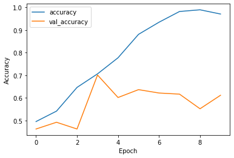

```python
# Ploting the training accuracy scores and validation accuracy scores across the epochs

plt.plot(cnn_model.history['accuracy'], label='accuracy')
plt.plot(cnn_model.history['val_accuracy'], label = 'val_accuracy')
plt.xlabel('Epoch')
plt.ylabel('Accuracy')
plt.legend()
```

**Comparison of the models**

Comparing the machine learning models after doing PCA and CNN model, we get the below results. CNN has obtained the highest validation accuracy score of 61.19 % among other models.

```python
performance_results_with_pca = performance_results_with_pca.append(model_results_cnn)
performance_results_with_pca
```

|  | Model | Validation Set Accuracy |
| --- | --- | --- |
| 0 | K-Nearest Neighbors | 53.17 |
| 0 | Support Vector Machine | 56.67 |
| 0 | Random Forest | 55.69 |
| 0 | Convolutional Neural Network | 61.19 |

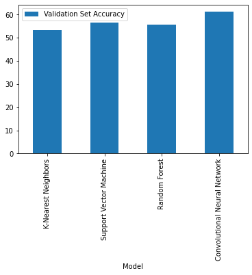

```python
# Comparison graphically of the models

data = pd.DataFrame({'Model': performance_results_with_pca['Model'],'Validation Set Accuracy':performance_results_with_pca['Validation Set Accuracy']})
data.plot.bar(x="Model", y=["Validation Set Accuracy"])
plt.show()
```

**Hyperparameter tuning of CNN**

Among the 4 models, CNN has obtained the highest validation accuracy score of 61.19 %. Now, we will do Hyperparameter tuning of CNN by giving various values of dropout rate and learning rate parameters. Hyperparameter tuning can be done with many parameters in CNN such as dropout rate, learning rate, number of epochs, number of neurons, activation functions, optimizers. We have considered two of the parameters: dropout rate and learning rate.

Including a Dropout layer will help in the reducing the overfitting of the model.

```python
def cnn_model(dropout_rate=0,learning_rate=0.01):

    # create model
    model1 = Sequential()
    model1.add(Conv2D(32, (3, 3), activation='relu', input_shape=(350, 350, 3)))
    model1.add(MaxPooling2D(pool_size=(2, 2)))
    model1.add(Dropout(dropout_rate))

    model1.add(Conv2D(64, (3, 3), activation='relu'))
    model1.add(MaxPooling2D(pool_size=(2, 2)))
    model1.add(Dropout(dropout_rate))

    model1.add(Conv2D(128, (3, 3), activation='relu'))
    model1.add(MaxPooling2D(pool_size=(2, 2)))
    model1.add(Dropout(dropout_rate))

    model1.add(Flatten())
    model1.add(Dense(64, activation='relu'))
    model1.add(Dropout(dropout_rate))
    model1.add(Dense(1, activation='sigmoid')) # 2 because we have cat and dog classes

    optimizer = keras.optimizers.Adam(learning_rate=learning_rate)
    model1.compile(loss='binary_crossentropy', optimizer = optimizer, metrics=['accuracy'])

    return model1
```

```python
model1 = cnn_model()
```

```python
model1.summary()
```

```
Model: "sequential_1"
_________________________________________________________________
Layer (type)                 Output Shape              Param #
=================================================================
conv2d_3 (Conv2D)            (None, 348, 348, 32)      896
_________________________________________________________________
max_pooling2d_3 (MaxPooling2 (None, 174, 174, 32)      0
_________________________________________________________________
dropout (Dropout)            (None, 174, 174, 32)      0
_________________________________________________________________
conv2d_4 (Conv2D)            (None, 172, 172, 64)      18496
_________________________________________________________________
max_pooling2d_4 (MaxPooling2 (None, 86, 86, 64)        0
_________________________________________________________________
dropout_1 (Dropout)          (None, 86, 86, 64)        0
_________________________________________________________________
conv2d_5 (Conv2D)            (None, 84, 84, 128)       73856
_________________________________________________________________
max_pooling2d_5 (MaxPooling2 (None, 42, 42, 128)       0
_________________________________________________________________
dropout_2 (Dropout)          (None, 42, 42, 128)       0
_________________________________________________________________
flatten_1 (Flatten)          (None, 225792)            0
_________________________________________________________________
dense_2 (Dense)              (None, 64)                14450752
_________________________________________________________________
dropout_3 (Dropout)          (None, 64)                0
_________________________________________________________________
dense_3 (Dense)              (None, 1)                 65
=================================================================
Total params: 14,544,065
Trainable params: 14,544,065
Non-trainable params: 0
_________________________________________________________________
```

With GridSearchCV, we can do various combinations with the 'dropout_rate'as [0.25, 0.50] and 'learning_rate' as [0.001, 0.01, 0.1]. We can obtain the best parameter after tuning.

```python
# create model
modelk = KerasClassifier(build_fn=create_mlp_model, verbose=1)

# define parameters and values for grid search
param_grid = {
    'dropout_rate': [0.25, 0.50],
    'learning_rate' : [0.001, 0.01, 0.1]
}
grid = GridSearchCV(estimator=modelk, param_grid=param_grid, cv=3)
grid_result = grid.fit(training_set_image_data, classes,epochs=5, batch_size=32)  # fit the full dataset as we are using cross validation
print("Best: %f using %s" % (grid_result.best_score_, grid_result.best_params_))
```

```
Best: 0.166667 using {'dropout_rate': 0.25, 'learning_rate': 0.001}
```

```python
# print best parameter after tuning
print(grid_result.best_params_)
```

```
{'dropout_rate': 0.25, 'learning_rate': 0.001}
```

After hyperparameter tuning, we obtained the best parameters with the values of dropout_rate as 0.25 and learning_rate as 0.001. We will now build the model again with these values with the dropout layer included in our model.

```python
def tuned_cnn_model(dropout_rate=0.25,learning_rate=0.001):

    # create model
    tuned_model = Sequential()
    tuned_model.add(Conv2D(32, (3, 3), activation='relu', input_shape=(350, 350, 3)))
    tuned_model.add(MaxPooling2D(pool_size=(2, 2)))
    tuned_model.add(Dropout(dropout_rate))

    tuned_model.add(Conv2D(64, (3, 3), activation='relu'))
    tuned_model.add(MaxPooling2D(pool_size=(2, 2)))
    tuned_model.add(Dropout(dropout_rate))

    tuned_model.add(Conv2D(128, (3, 3), activation='relu'))
    tuned_model.add(MaxPooling2D(pool_size=(2, 2)))
    tuned_model.add(Dropout(dropout_rate))

    tuned_model.add(Flatten())
    tuned_model.add(Dense(64, activation='relu'))
    tuned_model.add(Dropout(dropout_rate))
    tuned_model.add(Dense(1, activation='sigmoid'))

    optimizer = keras.optimizers.Adam(learning_rate=learning_rate)
    tuned_model.compile(loss='binary_crossentropy', optimizer = optimizer, metrics=['accuracy'])

    return tuned_model
```

```python
tuned_model = tuned_cnn_model(dropout_rate=0.25,learning_rate=0.001)
tuned_cnn_model = tuned_model.fit(train_features,train_class, epochs=10, batch_size=32, validation_data = (val_features, val_class))
```

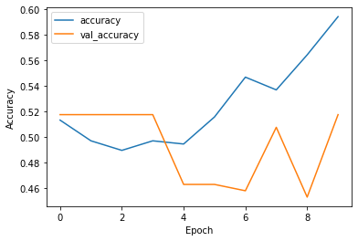

```python
# Ploting the training accuracy scores and validation accuracy scores across the epochs

plt.plot(tuned_cnn_model.history['accuracy'], label='accuracy')
plt.plot(tuned_cnn_model.history['val_accuracy'], label = 'val_accuracy')
plt.xlabel('Epoch')
plt.ylabel('Accuracy')
plt.legend()
```

After running the tuned model with the dropout layer included, values of dropout_rate as 0.25 and learning_rate as 0.001, we obtained the training accuracy score of 59.43 %. Problem of overfitting was addressed by adding the dropout layer.

**Prediction for the Test Set**

We now perform the same set of pre-processing methods for the Test Set that was applied on the training set.

```python
# Test Set
test_set_images_path = "C:/Users/dalal/Desktop/CIT Modules + Lectures + Materials/- Sem 2/Applied Machine Learning - COMP9060_26651/Project 3/Project3_files/Project3_files/data/test/"
test_set_images = os.listdir(test_set_images_path)

# We will now load the images of the Test set in form of an array
test_set_image_data = []

for image in test_set_images:
    # Reading the image using imread function
    original_image = cv2.imread(os.path.join(test_set_images_path,image))

    #Convert the image to RGB (Original image)
    image_rgb = cv2.cvtColor(original_image,cv2.COLOR_BGR2RGB)

    # Rescaling the image to 350 width X 350 height (350 X 350)
    image_rescale = cv2.resize(image_rgb,(350, 350))

    test_set_image_data.append(image_rescale)
```

```python
# Converting the image data matrix into 4-dimensional numpy array using reshape
test_set_image_data = np.array(test_set_image_data).reshape(-1,350,350,3)

# Normalizing the image matrix data
test_set_image_data = test_set_image_data/255

test_set_image_data.shape
```

```
(100, 350, 350, 3)
```

```
(350, 350, 3)
```

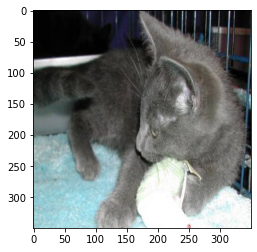

```python
plt.imshow(test_set_image_data[2])
print(test_set_image_data[2].shape)
```

**Predictions**

```python
predictions = tuned_model.predict(test_set_image_data)
```

```python
predicted_value = [int(round(p[0])) for p in predictions]
#predicted_value
```

**Conclusions**

The objective was to build models to classify whether images contain either a dog or a cat. We compared various classification models (machine learning algorithms and deep learning algorithms) and computed the accuracy of models and thereby selecting the most accurate model after fine tuning it.

From the models K-Nearest Neighbors, Support Vector Machine, Random Forest and Convolutional Neural Network (CNN), CNN achieved the highest validation accuracy score of 61.19 %. We then did hyperparameter tuning of CNN for the parameters: dropout rate and learning rate. After hyperparameter tuning, we obtained the best parameters with the values of dropout_rate as 0.25 and learning_rate as 0.001. We built the model again with these values with the dropout layer included in our model. After running the tuned model with the dropout layer included, values of dropout_rate as 0.25 and learning_rate as 0.001, we obtained the training accuracy score of 59.43 %. Problem of overfitting was addressed by adding the dropout layer.